# Fashion MNIST

### Fateme Seyyed Dabbaghi 810197529

#### Fashion-MNIST is a dataset consisting of a training set of 60000 pictures and a test set of 10000 examples. Each example is a 28x28 image, associated with a label from 10 classes. Each pixel has a single pixel-value associated with it, indicating the lightness or darkness of that pixel, with higher numbers meaning darker. This pixel-value is an integer between 0 and 255.

In this project, we are going to implement a feed-forward neural network and we will use the dataset introduced above to train our network. After training the network we will see the effects of different hyperparameters.

### Phase 1: Data set

```python
import numpy as np
import pandas as pd
from matplotlib import pyplot
```

```python
trainData = pd.read_csv("trainData.csv", header=None)
trainData
```

|  | 0 | 1 | 2 | 3 | 4 | 5 | 6 | 7 | 8 | 9 | ... | 774 | 775 | 776 | 777 | 778 | 779 | 780 | 781 | 782 | 783 |
| --- | --- | --- | --- | --- | --- | --- | --- | --- | --- | --- | --- | --- | --- | --- | --- | --- | --- | --- | --- | --- | --- |
| 0 | 0 | 0 | 0 | 0 | 0 | 0 | 0 | 0 | 0 | 0 | ... | 0 | 0 | 0 | 0 | 0 | 0 | 0 | 0 | 0 | 0 |
| 1 | 0 | 0 | 0 | 0 | 0 | 1 | 0 | 0 | 0 | 0 | ... | 119 | 114 | 130 | 76 | 0 | 0 | 0 | 0 | 0 | 0 |
| 2 | 0 | 0 | 0 | 0 | 0 | 0 | 0 | 0 | 0 | 22 | ... | 0 | 0 | 1 | 0 | 0 | 0 | 0 | 0 | 0 | 0 |
| 3 | 0 | 0 | 0 | 0 | 0 | 0 | 0 | 0 | 33 | 96 | ... | 0 | 0 | 0 | 0 | 0 | 0 | 0 | 0 | 0 | 0 |
| 4 | 0 | 0 | 0 | 0 | 0 | 0 | 0 | 0 | 0 | 0 | ... | 0 | 0 | 0 | 0 | 0 | 0 | 0 | 0 | 0 | 0 |
| ... | ... | ... | ... | ... | ... | ... | ... | ... | ... | ... | ... | ... | ... | ... | ... | ... | ... | ... | ... | ... | ... |
| 59995 | 0 | 0 | 0 | 0 | 0 | 0 | 0 | 0 | 0 | 0 | ... | 0 | 0 | 0 | 0 | 0 | 0 | 0 | 0 | 0 | 0 |
| 59996 | 0 | 0 | 0 | 0 | 0 | 0 | 0 | 0 | 0 | 0 | ... | 0 | 0 | 0 | 0 | 0 | 0 | 0 | 0 | 0 | 0 |
| 59997 | 0 | 0 | 0 | 0 | 0 | 0 | 0 | 0 | 0 | 5 | ... | 0 | 0 | 0 | 0 | 0 | 0 | 0 | 0 | 0 | 0 |
| 59998 | 0 | 0 | 0 | 0 | 0 | 0 | 0 | 0 | 0 | 0 | ... | 66 | 54 | 50 | 5 | 0 | 1 | 0 | 0 | 0 | 0 |
| 59999 | 0 | 0 | 0 | 0 | 0 | 0 | 0 | 0 | 0 | 0 | ... | 0 | 0 | 0 | 0 | 0 | 0 | 0 | 0 | 0 | 0 |

60000 rows × 784 columns

```python
trainLabels = pd.read_csv("trainLabels.csv", header=None)
trainLabels
```

|  | 0 |
| --- | --- |
| 0 | 9 |
| 1 | 0 |
| 2 | 0 |
| 3 | 3 |
| 4 | 0 |
| ... | ... |
| 59995 | 5 |
| 59996 | 1 |
| 59997 | 3 |
| 59998 | 0 |
| 59999 | 5 |

60000 rows × 1 columns

```python
testData = pd.read_csv("testData.csv", header=None)
testData
```

|  | 0 | 1 | 2 | 3 | 4 | 5 | 6 | 7 | 8 | 9 | ... | 774 | 775 | 776 | 777 | 778 | 779 | 780 | 781 | 782 | 783 |
| --- | --- | --- | --- | --- | --- | --- | --- | --- | --- | --- | --- | --- | --- | --- | --- | --- | --- | --- | --- | --- | --- |
| 0 | 0 | 0 | 0 | 0 | 0 | 0 | 0 | 0 | 0 | 0 | ... | 0 | 0 | 0 | 0 | 0 | 0 | 0 | 0 | 0 | 0 |
| 1 | 0 | 0 | 0 | 0 | 0 | 0 | 0 | 0 | 0 | 0 | ... | 2 | 3 | 0 | 3 | 174 | 189 | 67 | 0 | 0 | 0 |
| 2 | 0 | 0 | 0 | 0 | 0 | 0 | 0 | 0 | 1 | 0 | ... | 164 | 58 | 0 | 0 | 0 | 0 | 0 | 0 | 0 | 0 |
| 3 | 0 | 0 | 0 | 0 | 0 | 0 | 0 | 0 | 0 | 21 | ... | 1 | 0 | 0 | 0 | 0 | 0 | 0 | 0 | 0 | 0 |
| 4 | 0 | 0 | 0 | 2 | 0 | 1 | 1 | 0 | 0 | 0 | ... | 71 | 12 | 0 | 0 | 0 | 0 | 0 | 0 | 0 | 0 |
| ... | ... | ... | ... | ... | ... | ... | ... | ... | ... | ... | ... | ... | ... | ... | ... | ... | ... | ... | ... | ... | ... |
| 9995 | 0 | 0 | 0 | 0 | 0 | 0 | 0 | 0 | 0 | 0 | ... | 0 | 0 | 0 | 0 | 0 | 0 | 0 | 0 | 0 | 0 |
| 9996 | 0 | 0 | 0 | 0 | 0 | 0 | 0 | 0 | 0 | 31 | ... | 0 | 0 | 0 | 0 | 0 | 0 | 0 | 0 | 0 | 0 |
| 9997 | 0 | 0 | 0 | 0 | 0 | 0 | 0 | 0 | 0 | 0 | ... | 27 | 0 | 0 | 0 | 0 | 0 | 0 | 0 | 0 | 0 |
| 9998 | 0 | 0 | 0 | 0 | 0 | 0 | 0 | 0 | 0 | 0 | ... | 0 | 0 | 0 | 0 | 0 | 0 | 0 | 0 | 0 | 0 |
| 9999 | 0 | 0 | 0 | 0 | 0 | 0 | 0 | 0 | 0 | 0 | ... | 0 | 0 | 0 | 0 | 0 | 0 | 0 | 0 | 0 | 0 |

10000 rows × 784 columns

```python
testLabels = pd.read_csv("testLabels.csv", header=None)
testLabels
```

|  | 0 |
| --- | --- |
| 0 | 9 |
| 1 | 2 |
| 2 | 1 |
| 3 | 1 |
| 4 | 6 |
| ... | ... |
| 9995 | 9 |
| 9996 | 1 |
| 9997 | 8 |
| 9998 | 1 |
| 9999 | 5 |

10000 rows × 1 columns

### One data from each class

```python
for i in range(10):
    print("label: ",i)
    Index_label = trainLabels[trainLabels[0] == i].index.tolist()
    print(trainData.iloc[Index_label[0]])
```

```
label:  0
0      0
1      0
2      0
3      0
4      0
      ..
779    0
780    0
781    0
782    0
783    0
Name: 1, Length: 784, dtype: int64
label:  1
0      0
```

[output cut: 115 more lines]

```python
n_samples = len(testData.index)
images = testData.to_numpy()
labels = testLabels.to_numpy()
images = images.reshape(n_samples,28,28)
```

[figure not shown]

```python
pyplot.figure(figsize=(10,20))
for i in range(0,49) :
    pyplot.subplot(10,5,i+1)
    pyplot.axis('off')
    pyplot.imshow(images[i], cmap="gray_r")
    pyplot.title(labels[i][0])
```

### bar plots of the abundance of data in each class

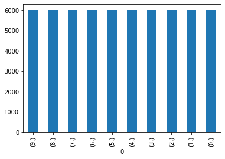

```python
trainLabels.value_counts().plot.bar()
```

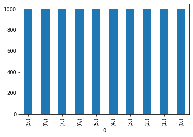

```python
testLabels.value_counts().plot.bar()
```

As can be seen, the data are evenly distributed

### Normalizing data

```python
trainData = trainData/2550
testData = testData/2550
trainData = trainData.to_numpy()
testData = testData.to_numpy()
trainLabels = np.genfromtxt('trainLabels.csv', delimiter=',')
testLabels = np.genfromtxt('testLabels.csv', delimiter=',')
```

### Phase 2: complete functions

# Dataloader

```python
class Dataloader:

    def __init__(self, data, labels, n_classes, batch_size=None, shuffle=False):
        assert len(data)==len(labels)
        self.__n_classes = n_classes
        self.__batch_size = batch_size
        self.__shuffle = shuffle
        self.__data = data
        self.__onehot_labels = self.__onehot(labels, self.__n_classes)

    def __onehot(self, labels, n_classes):
        onehot_vectors = list()
        for value in labels:
            letter = [0 for _ in range(n_classes)]
            letter[int(value)] = 1
            onehot_vectors.append(letter)
        onehot_vectors = np.asmatrix(onehot_vectors)
        return onehot_vectors

    def __shuffle_dataset(self):
        p = np.random.permutation(len(self.__data))
        self.__data = self.__data[p]
        self.__onehot_labels = self.__onehot_labels[p]

    def __iter__(self):

        if self.__shuffle:
            self.__shuffle_dataset()

        if self.__batch_size==None:
            yield (np.matrix(self.__data), np.matrix(self.__onehot_labels))
            return

        for idx in range(0, len(self.__data), self.__batch_size):
            yield (np.matrix(self.__data[idx:idx+self.__batch_size]),
                   np.matrix(self.__onehot_labels[idx:idx+self.__batch_size]))
```

# Activation Functions

```python
class Identical:

    def __init__(self): pass

    def __val(self, matrix):
        identical_value = np.matrix(matrix, dtype=float)
        return identical_value

    def derivative(self, matrix):
        temp = np.matrix(matrix, dtype=float)
        identical_derivative = np.matrix(np.full(np.shape(temp), 1.))
        return identical_derivative

    def __call__(self, matrix):
        return self.__val(matrix)


class Relu:

    def __init__(self): pass

    def __relu(self, matrix):
        relu_value = np.matrix(np.maximum(0,matrix), dtype=float)
        return relu_value

    def derivative(self, matrix):
        matrix[matrix<=0] = 0
        matrix[matrix>0] = 1
        relu_derivative = np.matrix(matrix, dtype=float)
        return relu_derivative

    def __call__(self, matrix):
        return self.__relu(matrix)


class LeakyRelu:

    def __init__(self, negative_slope=0.01):
        self.negative_slope = 0.01

    def __val(self, matrix):
        matrix = np.where(matrix > 0, matrix, matrix * self.negative_slope)
        leacky_relu_value = np.matrix(matrix, dtype=float)
        return leacky_relu_value

    def derivative(self, matrix):
        matrix[matrix<=0] = self.negative_slope
        matrix[matrix>0] = 1
        leacky_relu_derivative = np.matrix(matrix, dtype=float)
        return leacky_relu_derivative

    def __call__(self, matrix):
        return self.__val(matrix)


class Sigmoid:

    def __init__(self): pass

    def __val(self, matrix):
        sigmoid_value = np.matrix(1/(1+np.exp(-matrix)), dtype=float)
        return sigmoid_value

    def derivative(self, matrix):
        sigmoid_derivative = np.multiply(self.__val(matrix),(1-self.__val(matrix)))
        return sigmoid_derivative

    def __call__(self, matrix):
        return self.__val(matrix)

class Tanh:

    def __init__(self): pass

    def __val(self, matrix):
        tanh_value = np.tanh(matrix)
        return tanh_value

    def derivative(self, matrix):
        tanh_derivative = 1-np.multiply(np.tanh(matrix),np.tanh(matrix))
        return tanh_derivative

    def __call__(self, matrix):
        return self.__val(matrix)


class Softmax:

    def __init__(self): pass

    def __val(self, matrix):
        z = matrix - matrix.max(1)
        numerator = np.exp(z)
        denominator = numerator.sum(1)
        softmax_value = np.matrix(numerator/denominator, dtype=float)
        return softmax_value

    def __call__(self, matrix):
        return self.__val(matrix)
```

# Loss Function

```python
class CrossEntropy: #(with softmax)

    def __init__(self): pass

    def __val(self, true_val, expected_val):
        assert np.shape(true_val)==np.shape(expected_val)
        softmax = Softmax()
        neural_out = softmax(true_val)
        temp = -1*np.multiply(expected_val,np.ma.log(neural_out))
        cross_entropy_value = temp.sum(1)
        return cross_entropy_value

    def derivative(self, true_val, expected_val):
        assert np.shape(true_val)==np.shape(expected_val)
        softmax = Softmax()
        neural_out = softmax(true_val)
        cross_entropy_derivative = neural_out - expected_val
        return cross_entropy_derivative

    def __call__(self, true_val, expected_val):
        return self.__val(true_val, expected_val)
```

# Layer

```python
class Layer:

    DEFAULT_LOW, DEFAULT_HIGH, DEFAULT_MEAN, DEFAULT_VAR = 0, 0.05, 0., 1.

    def __init__(self, input_size, output_size,
                 activation=Identical(), initial_weight='uniform', **initializing_parameters):

        self.__weight_initializer_dict = {'uniform':self.__uniform_weight, 'normal':self.__normal_weight}
        assert type(initial_weight)==str, 'Undefined activation function!'
        assert initial_weight in self.__weight_initializer_dict, 'Undefined weight initialization function!'

        self.__n_neurons = output_size
        weight_initializer = self.__weight_initializer_dict[initial_weight]
        self.__weight = weight_initializer(input_size, self.__n_neurons, **initializing_parameters)
        self.__bias = weight_initializer(1, self.__n_neurons, **initializing_parameters)
        self.__activation = activation

        self.__last_input = None
        self.__last_activation_input = None
        self.__last_activation_output = None
        self.__last_activation_derivative = None

    def forward(self, layer_input):
        assert np.ndim(layer_input)==2
        assert np.size(self.__weight,0) == np.size(layer_input,1)
        self.__last_input = layer_input
        self.__last_activation_input = np.matmul(self.__last_input, self.__weight) + self.__bias
        self.__last_activation_output = self.__activation(self.__last_activation_input)
        self.__last_activation_derivative = self.__activation.derivative(self.__last_activation_input)
        return self.__last_activation_output

    def update_weights(self, backprop_tensor, lr):
        assert np.ndim(backprop_tensor)==2
        assert np.size(backprop_tensor,0) == np.size(self.__last_activation_derivative,0)
        assert np.size(backprop_tensor,1) == self.__n_neurons
        temp1 = self.__last_input.transpose()
        temp2 = np.multiply(backprop_tensor,self.__last_activation_derivative)
        err_w = np.matmul(temp1,temp2)
        temp3 = np.matmul(temp2,self.__weight.transpose())
        self.__weight = self.__weight - err_w*lr
        temp4 = np.matmul(np.matrix(np.tile(1, (1, temp2.shape[0]))),temp2)
        self.__bias = self.__bias - temp4*lr
        backprop_tensor = temp3
        return backprop_tensor

    def __uniform_weight(self, dim1, dim2, **initializing_parameters):
        low, high = self.DEFAULT_LOW, self.DEFAULT_HIGH
        if 'low' in initializing_parameters.keys(): low = initializing_parameters['low']
        if 'high' in initializing_parameters.keys(): high = initializing_parameters['high']
        d_arr = np.random.uniform(low, high, size=(dim1,dim2))
        weights = np.matrix(d_arr, dtype=float)
        return weights

    def __normal_weight(self, dim1, dim2, **initializing_parameters):
        mean, var = self.DEFAULT_MEAN, self.DEFAULT_VAR
        if 'mean' in initializing_parameters.keys(): mean = initializing_parameters['mean']
        if 'var' in initializing_parameters.keys(): var = initializing_parameters['var']
        y = np.random.normal(loc=mean, scale=np.sqrt(var), size=(dim1, dim2))
        weights = np.matrix(y ,dtype=float)
        return weights

    @property
    def n_neurons(self): return self.__n_neurons

    @property
    def weight(self): return self.__weight

    @property
    def bias(self): return self.__bias

    @property
    def activation(self): return self.__activation
```

# Feed Forward Neural Network

```python
class FeedForwardNN:

    def __init__(self, input_shape):

        self.__input_shape = input_shape
        self.__output_shape = None

        self.__layers_list = []

        self.__lr = None
        self.__loss = None


    def add_layer(self, n_neurons, activation=Relu(), initial_weight='uniform', **initializing_parameters):

        assert type(n_neurons)==int, "Invalid number of neurons for the layer!"
        assert n_neurons>0, "Invalid number of neurons for the layer!"

        n_prev_neurons = self.__input_shape if len(self.__layers_list)==0 else self.__layers_list[-1].n_neurons
        new_layer = Layer(n_prev_neurons, n_neurons, activation, initial_weight, **initializing_parameters)
        self.__layers_list.append(new_layer)
        self.__output_shape = self.__layers_list[-1].n_neurons


    def set_training_param(self, loss=CrossEntropy(), lr=1e-3):
        assert self.__layers_list, "Uncomplete model!"
        self.__loss = loss
        self.__lr = lr


    def forward(self, network_input,on_off,h):
        assert type(self.__output_shape) != None, "Model is not compiled!"
        network_output = network_input
        j = 1

        for i in self.__layers_list:
            network_output = i.forward(network_output)
            if j == layer_1 and h==1:
                if on_off == 0:
                    plot_data_train.append(network_output)
                else:
                    plot_data_test.append(network_output)
            j += 1
        return network_output


    def fit(self, epochs, trainloader, testloader=None, print_results=True):

        assert type(self.__output_shape) != None, "Model is not compiled!"
        assert type(self.__lr) != None and type(self.__loss) != None, "Training paramenters are not set!"

        log = {"train_accuracy":[], "train_loss":[], "test_accuracy":[], "test_loss":[]}

        for epoch in range(1, epochs+1):

            if print_results:
                print('Epoch {}:'.format(epoch))
            h = 0
            if epoch ==epochs:
                h=1
            average_accuracy, average_loss = self.__train(trainloader,h)
            log['train_accuracy'].append(average_accuracy)
            log['train_loss'].append(average_loss)
            if print_results:
                print('\tTrain: Average Accuracy: {}\tAverage Loss: {}'.format(average_accuracy, average_loss))

            if type(testloader) != type(None):
                average_accuracy, average_loss = self.__test(testloader,h)
                log['test_accuracy'].append(average_accuracy)
                log['test_loss'].append(average_loss)
                if print_results:
                    print('\tTest: Average Accuracy: {}\tAverage Loss: {}'.format(average_accuracy, average_loss))

        return log


    def __train(self, trainloader,h):
        bach_accuracies, batch_losses = [], []
        for x_train, y_train in trainloader:
            batch_accuracy, batch_loss = self.__train_on_batch(x_train, y_train,h)
            bach_accuracies.append(batch_accuracy)
            batch_losses.append(batch_loss)
        return np.mean(bach_accuracies), np.mean(batch_losses)


    def __test(self, testloader,h):
        bach_accuracies, batch_losses = [], []
        plot_data_test = []
        for x_test, y_test in testloader:
            batch_accuracy, batch_loss = self.__test_on_batch(x_test, y_test,h)
            bach_accuracies.append(batch_accuracy)
            batch_losses.append(batch_loss)
        return np.mean(bach_accuracies), np.mean(batch_losses)


    def __train_on_batch(self, x_batch, y_batch,h):
        temp = self.forward(x_batch,0,h)
        batch_accuracy = self.__compute_accuracy(temp,y_batch)
        batch_average_loss = self.__update_weights(temp, y_batch)
        return (batch_accuracy, batch_average_loss)


    def __test_on_batch(self, x_batch, y_batch,h):
        temp = self.forward(x_batch,1,h)
        batch_accuracy = self.__compute_accuracy(temp,y_batch)
        cross_entropy = CrossEntropy()
        batch_loss = cross_entropy(temp, y_batch)
        batch_average_loss = np.sum(batch_loss)/len(temp)
        return (batch_accuracy, batch_average_loss)

    def __compute_accuracy(self, output, expected_output):
        output = np.array(output)
        result1 = np.argmax(output, axis=1)
        expected_output = np.array(expected_output)
        result2 = np.argmax(expected_output, axis=1)
        true = np.sum(result1 == result2)
        accuracy = true/len(result1)*100
        return accuracy

    def __update_weights(self, output, y_batch):
        cross_entropy = CrossEntropy()
        batch_loss = cross_entropy(output, y_batch)
        batch_average_loss = np.sum(batch_loss)/len(output)
        temp = cross_entropy.derivative(output, y_batch)
        for i in reversed(self.__layers_list):
            temp = i.update_weights(temp, self.__lr)
        return batch_average_loss
```

# Training Sample Code

#### 1) The desired network with the most appropriate learning rate

Relu activation function: For the advantages Reli os computationally efficient. allows the network to converge very quickly. Non-linear although it looks like a linear function, ReLU has a derivative function and allows for backpropagation. But it has the Dying ReLU problem when inputs approach zero, or are negative, the gradient of the function becomes zero, the network cannot perform backpropagation and cannot learn.

```python
INPUT_SHAPE = 784
LEARNING_RATE = 0.01
EPOCHS = 30
TRAINLOADER = []
train_loader = Dataloader(trainData, trainLabels, 10, batch_size=32, shuffle=True)
for i in train_loader:
    TRAINLOADER.append(i)
TESTLOADER = []
test_loader = Dataloader(testData, testLabels, 10, batch_size=32, shuffle=True)
for i in test_loader:
    TESTLOADER.append(i)

plot_data_test = []
plot_data_train = []
layer_1 = 0

network = FeedForwardNN(INPUT_SHAPE)
network.add_layer(20, input_shape=INPUT_SHAPE, activation=Relu(), initial_weight='uniform')
network.add_layer(10, activation=Identical(), initial_weight='uniform')
network.set_training_param(loss=CrossEntropy(), lr=LEARNING_RATE)

log = network.fit(EPOCHS, TRAINLOADER, TESTLOADER)
```

```
Epoch 1:
	Train: Average Accuracy: 68.22833333333334	Average Loss: 0.8614307221253515
	Test: Average Accuracy: 79.07348242811501	Average Loss: 0.5820774024809195
Epoch 2:
	Train: Average Accuracy: 81.175	Average Loss: 0.5265812048728256
	Test: Average Accuracy: 82.00878594249201	Average Loss: 0.5062113879749923
Epoch 3:
	Train: Average Accuracy: 83.075	Average Loss: 0.4741216412230843
	Test: Average Accuracy: 82.83746006389777	Average Loss: 0.48015970596899527
Epoch 4:
	Train: Average Accuracy: 83.97	Average Loss: 0.44702373815398
	Test: Average Accuracy: 83.32667731629392	Average Loss: 0.46084292507669633
Epoch 5:
	Train: Average Accuracy: 84.655	Average Loss: 0.428810147757127
	Test: Average Accuracy: 83.68610223642173	Average Loss: 0.4492381957761547
Epoch 6:
	Train: Average Accuracy: 85.12333333333333	Average Loss: 0.41473280384340494
	Test: Average Accuracy: 84.05551118210863	Average Loss: 0.44090555009744603
Epoch 7:
	Train: Average Accuracy: 85.56833333333333	Average Loss: 0.40356462973912116
	Test: Average Accuracy: 84.32507987220447	Average Loss: 0.43534494369291027
Epoch 8:
	Train: Average Accuracy: 85.86333333333333	Average Loss: 0.39421245112273245
	Test: Average Accuracy: 84.32507987220447	Average Loss: 0.43306647889305544
Epoch 9:
	Train: Average Accuracy: 86.08	Average Loss: 0.38666743678529686
	Test: Average Accuracy: 84.51477635782747	Average Loss: 0.42925800558508664
Epoch 10:
	Train: Average Accuracy: 86.375	Average Loss: 0.379825975202894
	Test: Average Accuracy: 84.70447284345047	Average Loss: 0.4259414952601158
Epoch 11:
	Train: Average Accuracy: 86.54	Average Loss: 0.37368428491170175
	Test: Average Accuracy: 84.79432907348243	Average Loss: 0.42272335422193885
Epoch 12:
	Train: Average Accuracy: 86.745	Average Loss: 0.36812245117227743
	Test: Average Accuracy: 85.00399361022365	Average Loss: 0.4197545465072288
Epoch 13:
	Train: Average Accuracy: 86.90333333333334	Average Loss: 0.3630019378617858
	Test: Average Accuracy: 84.99400958466454	Average Loss: 0.4169403612256044
Epoch 14:
```

[output cut: 35 more lines]

```
Epoch 26:
	Train: Average Accuracy: 88.43	Average Loss: 0.320699253203454
	Test: Average Accuracy: 86.0523162939297	Average Loss: 0.4005406456858
Epoch 27:
	Train: Average Accuracy: 88.50166666666667	Average Loss: 0.3185727886637394
	Test: Average Accuracy: 86.0123801916933	Average Loss: 0.3979404486873735
Epoch 28:
	Train: Average Accuracy: 88.595	Average Loss: 0.3163971590093094
	Test: Average Accuracy: 86.07228434504792	Average Loss: 0.39808251646502335
Epoch 29:
	Train: Average Accuracy: 88.65	Average Loss: 0.3144424347699324
	Test: Average Accuracy: 86.13218849840256	Average Loss: 0.39573135064483683
Epoch 30:
	Train: Average Accuracy: 88.70666666666666	Average Loss: 0.31245132308128204
	Test: Average Accuracy: 86.29193290734824	Average Loss: 0.3935900003799289
```

### Learning rate

The learning rate is a hyperparameter that controls how much to change the model in response to the estimated error each time the model weights are updated.

#### 2) Increasing learning rate

As we can see by increasing the learning rate we are stuck in the accuracy of 10 percent. Increasing the learning rate further will cause an increase in loss. But it might have a short term negative effect and yet achieve a longer term beneficial effect.

```python
LEARNING_RATE = 0.1

network = FeedForwardNN(INPUT_SHAPE)
network.add_layer(20, input_shape=INPUT_SHAPE, activation=Relu(), initial_weight='uniform')
network.add_layer(10, activation=Identical(), initial_weight='uniform')
network.set_training_param(loss=CrossEntropy(), lr=LEARNING_RATE)

log = network.fit(EPOCHS, TRAINLOADER, TESTLOADER)
```

```
Epoch 1:
	Train: Average Accuracy: 10.035	Average Loss: 2.330107385375467
	Test: Average Accuracy: 10.013977635782748	Average Loss: 2.314627908971276
Epoch 2:
	Train: Average Accuracy: 10.035	Average Loss: 2.3293667078914297
	Test: Average Accuracy: 10.013977635782748	Average Loss: 2.3146267623853602
Epoch 3:
	Train: Average Accuracy: 10.035	Average Loss: 2.3293649752868206
	Test: Average Accuracy: 10.013977635782748	Average Loss: 2.3146267623853602
Epoch 4:
	Train: Average Accuracy: 10.035	Average Loss: 2.3293649752868206
	Test: Average Accuracy: 10.013977635782748	Average Loss: 2.3146267623853602
Epoch 5:
	Train: Average Accuracy: 10.035	Average Loss: 2.3293649752868206
	Test: Average Accuracy: 10.013977635782748	Average Loss: 2.3146267623853602
Epoch 6:
	Train: Average Accuracy: 10.035	Average Loss: 2.3293649752868206
	Test: Average Accuracy: 10.013977635782748	Average Loss: 2.3146267623853602
Epoch 7:
	Train: Average Accuracy: 10.035	Average Loss: 2.3293649752868206
	Test: Average Accuracy: 10.013977635782748	Average Loss: 2.3146267623853602
Epoch 8:
	Train: Average Accuracy: 10.035	Average Loss: 2.3293649752868206
	Test: Average Accuracy: 10.013977635782748	Average Loss: 2.3146267623853602
Epoch 9:
	Train: Average Accuracy: 10.035	Average Loss: 2.3293649752868206
	Test: Average Accuracy: 10.013977635782748	Average Loss: 2.3146267623853602
Epoch 10:
	Train: Average Accuracy: 10.035	Average Loss: 2.3293649752868206
	Test: Average Accuracy: 10.013977635782748	Average Loss: 2.3146267623853602
Epoch 11:
	Train: Average Accuracy: 10.035	Average Loss: 2.3293649752868206
	Test: Average Accuracy: 10.013977635782748	Average Loss: 2.3146267623853602
Epoch 12:
	Train: Average Accuracy: 10.035	Average Loss: 2.3293649752868206
	Test: Average Accuracy: 10.013977635782748	Average Loss: 2.3146267623853602
Epoch 13:
	Train: Average Accuracy: 10.035	Average Loss: 2.3293649752868206
	Test: Average Accuracy: 10.013977635782748	Average Loss: 2.3146267623853602
Epoch 14:
```

[output cut: 35 more lines]

```
Epoch 26:
	Train: Average Accuracy: 10.035	Average Loss: 2.3293649752868206
	Test: Average Accuracy: 10.013977635782748	Average Loss: 2.3146267623853602
Epoch 27:
	Train: Average Accuracy: 10.035	Average Loss: 2.3293649752868206
	Test: Average Accuracy: 10.013977635782748	Average Loss: 2.3146267623853602
Epoch 28:
	Train: Average Accuracy: 10.035	Average Loss: 2.3293649752868206
	Test: Average Accuracy: 10.013977635782748	Average Loss: 2.3146267623853602
Epoch 29:
	Train: Average Accuracy: 10.035	Average Loss: 2.3293649752868206
	Test: Average Accuracy: 10.013977635782748	Average Loss: 2.3146267623853602
Epoch 30:
	Train: Average Accuracy: 10.035	Average Loss: 2.3293649752868206
	Test: Average Accuracy: 10.013977635782748	Average Loss: 2.3146267623853602
```

#### 3) Decreasing learning rate

By decreasing the learning rate over the network, we decrease our changes in w. In gradient descent learning algorithms such as error backpropagation, the learning rate parameter can have a significant effect on accuracy. In particular, decreasing the learning rate below that which yields the fastest convergence can significantly improve generalization accuracy, especially on large, complex problems.

```python
LEARNING_RATE = 0.001

network = FeedForwardNN(INPUT_SHAPE)
network.add_layer(20, input_shape=INPUT_SHAPE, activation=Relu(), initial_weight='uniform')
network.add_layer(10, activation=Identical(), initial_weight='uniform')
network.set_training_param(loss=CrossEntropy(), lr=LEARNING_RATE)

log = network.fit(EPOCHS, TRAINLOADER, TESTLOADER)
```

```
Epoch 1:
	Train: Average Accuracy: 32.065	Average Loss: 1.9117025762043016
	Test: Average Accuracy: 52.72563897763578	Average Loss: 1.3875848610267323
Epoch 2:
	Train: Average Accuracy: 60.248333333333335	Average Loss: 1.1387834510873776
	Test: Average Accuracy: 68.44049520766774	Average Loss: 0.9522209238523242
Epoch 3:
	Train: Average Accuracy: 71.545	Average Loss: 0.8314499687011393
	Test: Average Accuracy: 72.84345047923323	Average Loss: 0.7632847191833586
Epoch 4:
	Train: Average Accuracy: 74.27666666666667	Average Loss: 0.710662691849927
	Test: Average Accuracy: 74.56070287539936	Average Loss: 0.6931946070688058
Epoch 5:
	Train: Average Accuracy: 75.94333333333333	Average Loss: 0.6570434413923052
	Test: Average Accuracy: 75.85862619808307	Average Loss: 0.6536835958478091
Epoch 6:
	Train: Average Accuracy: 77.38666666666667	Average Loss: 0.6221665826497234
	Test: Average Accuracy: 77.0167731629393	Average Loss: 0.6253771530209344
Epoch 7:
	Train: Average Accuracy: 78.535	Average Loss: 0.5952847777823781
	Test: Average Accuracy: 77.82547923322684	Average Loss: 0.6027846150514896
Epoch 8:
	Train: Average Accuracy: 79.51833333333333	Average Loss: 0.5727482812167756
	Test: Average Accuracy: 78.81389776357827	Average Loss: 0.5833896365432645
Epoch 9:
	Train: Average Accuracy: 80.40833333333333	Average Loss: 0.5528239155445464
	Test: Average Accuracy: 79.78234824281151	Average Loss: 0.5660728234289514
Epoch 10:
	Train: Average Accuracy: 81.10333333333334	Average Loss: 0.5349940144937702
	Test: Average Accuracy: 80.35143769968052	Average Loss: 0.5508474132374814
Epoch 11:
	Train: Average Accuracy: 81.76166666666667	Average Loss: 0.5194400542325667
	Test: Average Accuracy: 80.84065495207668	Average Loss: 0.5379287436966996
Epoch 12:
	Train: Average Accuracy: 82.29	Average Loss: 0.5062932109148132
	Test: Average Accuracy: 81.40974440894568	Average Loss: 0.5272385536344341
Epoch 13:
	Train: Average Accuracy: 82.78	Average Loss: 0.4953507387413505
	Test: Average Accuracy: 81.85902555910543	Average Loss: 0.5184829170425802
Epoch 14:
```

[output cut: 35 more lines]

```
Epoch 26:
	Train: Average Accuracy: 85.08333333333333	Average Loss: 0.43353763956682206
	Test: Average Accuracy: 83.32667731629392	Average Loss: 0.46998028653384644
Epoch 27:
	Train: Average Accuracy: 85.15833333333333	Average Loss: 0.4311940173296189
	Test: Average Accuracy: 83.37659744408946	Average Loss: 0.46820807770112544
Epoch 28:
	Train: Average Accuracy: 85.23833333333333	Average Loss: 0.4289859314198771
	Test: Average Accuracy: 83.47643769968052	Average Loss: 0.4665626875335278
Epoch 29:
	Train: Average Accuracy: 85.30666666666667	Average Loss: 0.42691225451364967
	Test: Average Accuracy: 83.49640575079871	Average Loss: 0.46497973692162814
Epoch 30:
	Train: Average Accuracy: 85.38	Average Loss: 0.42494113808237516
	Test: Average Accuracy: 83.58626198083067	Average Loss: 0.463507639623242
```

#### 4) Leaky Relu activation function

Overall this function performs better as compared to traditionally used activation functions such as Sigmoid and Hyperbolic-Tangent functions and even ReLU but in our architecture the result is not like this. It is fast and easy to calculate. It does not saturate for positive values of input and hence does not run into problems related to exploding/vanishing gradients during Gradient Descent.and it does not suffer from dying ReLU problem.  
But it may cause our result to overflow. and the value of α is defined prior to the training and hence cannot be adjusted during the training time. The value of α hence chosen might not be the most optimal value.

```python
LEARNING_RATE = 0.01

network = FeedForwardNN(INPUT_SHAPE)
network.add_layer(20, input_shape=INPUT_SHAPE, activation=LeakyRelu(), initial_weight='uniform')
network.add_layer(10, activation=Identical(), initial_weight='uniform')
network.set_training_param(loss=CrossEntropy(), lr=LEARNING_RATE)

log = network.fit(EPOCHS, TRAINLOADER, TESTLOADER)
```

```
Epoch 1:
	Train: Average Accuracy: 64.42	Average Loss: 1.0014125592785068
	Test: Average Accuracy: 75.83865814696486	Average Loss: 0.6965231488250992
Epoch 2:
	Train: Average Accuracy: 75.38833333333334	Average Loss: 0.7317673209235266
	Test: Average Accuracy: 76.99680511182109	Average Loss: 0.6825197622886342
Epoch 3:
	Train: Average Accuracy: 75.20833333333333	Average Loss: 0.7745921876988052
	Test: Average Accuracy: 76.93690095846645	Average Loss: 0.7025379808825073
Epoch 4:
	Train: Average Accuracy: 74.48666666666666	Average Loss: 0.8229671488404279
	Test: Average Accuracy: 76.33785942492013	Average Loss: 0.727532400561609
Epoch 5:
	Train: Average Accuracy: 74.11833333333334	Average Loss: 0.8552666542759481
	Test: Average Accuracy: 76.32787539936102	Average Loss: 0.7420465178353861
Epoch 6:
	Train: Average Accuracy: 74.15166666666667	Average Loss: 0.8520205255237069
	Test: Average Accuracy: 74.28115015974441	Average Loss: 1.0193684137941261
Epoch 7:
	Train: Average Accuracy: 74.37166666666667	Average Loss: 0.8371640539270305
	Test: Average Accuracy: 74.34105431309904	Average Loss: 0.8933402539553081
Epoch 8:
	Train: Average Accuracy: 74.91666666666667	Average Loss: 0.8301915035653343
	Test: Average Accuracy: 75.26956869009585	Average Loss: 0.8519062343192242
Epoch 9:
	Train: Average Accuracy: 75.20833333333333	Average Loss: 0.8274033792889509
	Test: Average Accuracy: 75.96845047923323	Average Loss: 0.82996111198798
Epoch 10:
	Train: Average Accuracy: 75.45333333333333	Average Loss: 0.8294729260642205
	Test: Average Accuracy: 75.53913738019169	Average Loss: 0.904552829352883
Epoch 11:
	Train: Average Accuracy: 75.725	Average Loss: 0.8315421098242575
	Test: Average Accuracy: 75.7388178913738	Average Loss: 0.9207220384731564
Epoch 12:
	Train: Average Accuracy: 75.77166666666666	Average Loss: 0.839644540081071
	Test: Average Accuracy: 75.03993610223642	Average Loss: 1.0101516912078765
Epoch 13:
	Train: Average Accuracy: 75.73833333333333	Average Loss: 0.8514472143966244
	Test: Average Accuracy: 76.31789137380191	Average Loss: 0.8916804074133139
Epoch 14:
```

[output cut: 35 more lines]

```
Epoch 26:
	Train: Average Accuracy: 75.63333333333334	Average Loss: 0.9311699839839708
	Test: Average Accuracy: 73.3326677316294	Average Loss: 1.1259847751524936
Epoch 27:
	Train: Average Accuracy: 75.63166666666666	Average Loss: 0.9384892453459726
	Test: Average Accuracy: 73.53234824281151	Average Loss: 1.1041865235945074
Epoch 28:
	Train: Average Accuracy: 75.60333333333334	Average Loss: 0.9386430649718676
	Test: Average Accuracy: 75.49920127795527	Average Loss: 0.9953830399539265
Epoch 29:
	Train: Average Accuracy: 75.79333333333334	Average Loss: 0.9346883780177077
	Test: Average Accuracy: 75.82867412140575	Average Loss: 0.9542883124574882
Epoch 30:
	Train: Average Accuracy: 75.895	Average Loss: 0.9258234502971872
	Test: Average Accuracy: 76.50758785942492	Average Loss: 0.9485173306949769
```

#### 5) Sigmoid activation function

This activation function is a smooth gradient. Output values bound between 0 and 1 (normalizing the output of each neuron and preventing overflowing). But Vanishing gradient—for very high or very low values of X is possible, there is almost no change to the prediction, causing a vanishing gradient problem. This can result in the network refusing to learn further, or being too slow to reach an accurate prediction. And outputs not zero centered. And for the last disadvantage computationally expensive

```python
LEARNING_RATE = 0.01

network = FeedForwardNN(INPUT_SHAPE)
network.add_layer(20, input_shape=INPUT_SHAPE, activation=Sigmoid(), initial_weight='uniform')
network.add_layer(10, activation=Identical(), initial_weight='uniform')
network.set_training_param(loss=CrossEntropy(), lr=LEARNING_RATE)

log = network.fit(EPOCHS, TRAINLOADER, TESTLOADER)
```

```
Epoch 1:
	Train: Average Accuracy: 41.945	Average Loss: 1.5814609554236143
	Test: Average Accuracy: 67.51198083067092	Average Loss: 0.9449556986220855
Epoch 2:
	Train: Average Accuracy: 72.08666666666667	Average Loss: 0.76665048153516
	Test: Average Accuracy: 74.71046325878594	Average Loss: 0.6851316977869769
Epoch 3:
	Train: Average Accuracy: 76.70333333333333	Average Loss: 0.629426589639765
	Test: Average Accuracy: 77.31629392971246	Average Loss: 0.6113043502971983
Epoch 4:
	Train: Average Accuracy: 79.335	Average Loss: 0.5686272390351109
	Test: Average Accuracy: 79.59265175718849	Average Loss: 0.5662901384332865
Epoch 5:
	Train: Average Accuracy: 81.16666666666667	Average Loss: 0.5284044640597632
	Test: Average Accuracy: 80.72084664536742	Average Loss: 0.5363230100657147
Epoch 6:
	Train: Average Accuracy: 82.22666666666667	Average Loss: 0.5007941667100326
	Test: Average Accuracy: 81.52955271565496	Average Loss: 0.5158203509144301
Epoch 7:
	Train: Average Accuracy: 82.99333333333334	Average Loss: 0.48110579831331296
	Test: Average Accuracy: 82.14856230031948	Average Loss: 0.5010462320431469
Epoch 8:
	Train: Average Accuracy: 83.52833333333334	Average Loss: 0.4663743202770426
	Test: Average Accuracy: 82.50798722044729	Average Loss: 0.48988913029975734
Epoch 9:
	Train: Average Accuracy: 83.93	Average Loss: 0.4548496276966117
	Test: Average Accuracy: 82.9173322683706	Average Loss: 0.4810407992432833
Epoch 10:
	Train: Average Accuracy: 84.29666666666667	Average Loss: 0.44545532998621984
	Test: Average Accuracy: 83.17691693290735	Average Loss: 0.4737514400194588
Epoch 11:
	Train: Average Accuracy: 84.545	Average Loss: 0.4375638738057999
	Test: Average Accuracy: 83.29672523961662	Average Loss: 0.46759783230959484
Epoch 12:
	Train: Average Accuracy: 84.765	Average Loss: 0.4307963896786707
	Test: Average Accuracy: 83.49640575079871	Average Loss: 0.46231220292099806
Epoch 13:
	Train: Average Accuracy: 84.96	Average Loss: 0.4248996886195065
	Test: Average Accuracy: 83.6261980830671	Average Loss: 0.4577057499514724
Epoch 14:
```

[output cut: 35 more lines]

```
Epoch 26:
	Train: Average Accuracy: 86.49166666666666	Average Loss: 0.3822360566896475
	Test: Average Accuracy: 84.59464856230032	Average Loss: 0.42509853566272465
Epoch 27:
	Train: Average Accuracy: 86.56666666666666	Average Loss: 0.3801589709606742
	Test: Average Accuracy: 84.79432907348243	Average Loss: 0.4236182537983479
Epoch 28:
	Train: Average Accuracy: 86.62833333333333	Average Loss: 0.37816709374108876
	Test: Average Accuracy: 84.84424920127796	Average Loss: 0.42221833288993577
Epoch 29:
	Train: Average Accuracy: 86.71666666666667	Average Loss: 0.37625221815778787
	Test: Average Accuracy: 84.89416932907348	Average Loss: 0.4208920687670807
Epoch 30:
	Train: Average Accuracy: 86.75666666666666	Average Loss: 0.37440717846310373
	Test: Average Accuracy: 84.98402555910543	Average Loss: 0.419633468850125
```

#### 6) Tanh activation function

The advantages and disadvantages of this activation function are mostly like Sigmoid.

```python
LEARNING_RATE = 0.01

network = FeedForwardNN(INPUT_SHAPE)
network.add_layer(20, input_shape=INPUT_SHAPE, activation=Tanh(), initial_weight='uniform')
network.add_layer(10, activation=Identical(), initial_weight='uniform')
network.set_training_param(loss=CrossEntropy(), lr=LEARNING_RATE)

log = network.fit(EPOCHS, TRAINLOADER, TESTLOADER)
```

```
Epoch 1:
	Train: Average Accuracy: 68.18166666666667	Average Loss: 0.854717503469664
	Test: Average Accuracy: 78.21485623003196	Average Loss: 0.5869327965428772
Epoch 2:
	Train: Average Accuracy: 81.33166666666666	Average Loss: 0.5161454484521742
	Test: Average Accuracy: 81.78913738019169	Average Loss: 0.5052695685277593
Epoch 3:
	Train: Average Accuracy: 83.15	Average Loss: 0.4683037278285367
	Test: Average Accuracy: 82.95726837060703	Average Loss: 0.47787500441068725
Epoch 4:
	Train: Average Accuracy: 84.01166666666667	Average Loss: 0.44442571705312767
	Test: Average Accuracy: 83.32667731629392	Average Loss: 0.46304499121521814
Epoch 5:
	Train: Average Accuracy: 84.64666666666666	Average Loss: 0.4282468589519006
	Test: Average Accuracy: 83.85583067092652	Average Loss: 0.45266405688046185
Epoch 6:
	Train: Average Accuracy: 85.07833333333333	Average Loss: 0.4159403532995955
	Test: Average Accuracy: 83.97563897763578	Average Loss: 0.44457356882487725
Epoch 7:
	Train: Average Accuracy: 85.52166666666666	Average Loss: 0.40601769919323155
	Test: Average Accuracy: 84.26517571884985	Average Loss: 0.4380537539336231
Epoch 8:
	Train: Average Accuracy: 85.79	Average Loss: 0.39775359630918866
	Test: Average Accuracy: 84.40495207667732	Average Loss: 0.43276388680845
Epoch 9:
	Train: Average Accuracy: 86.045	Average Loss: 0.39069436589918005
	Test: Average Accuracy: 84.564696485623	Average Loss: 0.4284025977134341
Epoch 10:
	Train: Average Accuracy: 86.22666666666667	Average Loss: 0.38449869236440687
	Test: Average Accuracy: 84.81429712460064	Average Loss: 0.42466968044449765
Epoch 11:
	Train: Average Accuracy: 86.44833333333334	Average Loss: 0.3789034306509653
	Test: Average Accuracy: 85.01397763578275	Average Loss: 0.42131472350403115
Epoch 12:
	Train: Average Accuracy: 86.665	Average Loss: 0.3737230815546175
	Test: Average Accuracy: 85.07388178913737	Average Loss: 0.4181884994379336
Epoch 13:
	Train: Average Accuracy: 86.81333333333333	Average Loss: 0.36886020517972223
	Test: Average Accuracy: 85.16373801916933	Average Loss: 0.4152725132928806
Epoch 14:
```

[output cut: 35 more lines]

```
Epoch 26:
	Train: Average Accuracy: 88.11166666666666	Average Loss: 0.3281595853129135
	Test: Average Accuracy: 85.93250798722045	Average Loss: 0.3966078753424018
Epoch 27:
	Train: Average Accuracy: 88.15833333333333	Average Loss: 0.3260676436609607
	Test: Average Accuracy: 85.97244408945687	Average Loss: 0.3958045160598201
Epoch 28:
	Train: Average Accuracy: 88.22166666666666	Average Loss: 0.3240571424840645
	Test: Average Accuracy: 86.06230031948881	Average Loss: 0.395040552966531
Epoch 29:
	Train: Average Accuracy: 88.30666666666667	Average Loss: 0.32212114544224096
	Test: Average Accuracy: 86.11222044728434	Average Loss: 0.39431633400086197
Epoch 30:
	Train: Average Accuracy: 88.36166666666666	Average Loss: 0.32025359127715813
	Test: Average Accuracy: 86.15215654952077	Average Loss: 0.3936327442375848
```

#### 7,8) batch size

In general, smaller batches perform better on training data but may lead to overfitting. Also, training data with these categories can lead to hours and is slow. Larger batches are faster but less accurate. In our case 16 and 128 could not show the difference clearly, so we used smaller and larger numbers.  
Small batch size can converge faster than a large batch, but a large batch can reach the optimum minima that a small batch size cannot reach. Also, a small batch size can have a significant regularization effect because of its high variance, but it will require a small learning rate to prevent it from overshooting the minima.

```python
INPUT_SHAPE = 784
LEARNING_RATE = 0.01
EPOCHS = 30
TRAINLOADER = []
train_loader = Dataloader(trainData, trainLabels, 10, batch_size=16, shuffle=True)
for i in train_loader:
    TRAINLOADER.append(i)
TESTLOADER = []
test_loader = Dataloader(testData, testLabels, 10, batch_size=16, shuffle=True)
for i in test_loader:
    TESTLOADER.append(i)

network = FeedForwardNN(INPUT_SHAPE)
network.add_layer(20, input_shape=INPUT_SHAPE, activation=Relu(), initial_weight='uniform')
network.add_layer(10, activation=Identical(), initial_weight='uniform')
network.set_training_param(loss=CrossEntropy(), lr=LEARNING_RATE)

log = network.fit(EPOCHS, TRAINLOADER, TESTLOADER)
```

```
Epoch 1:
	Train: Average Accuracy: 68.29833333333333	Average Loss: 0.8552720491145186
	Test: Average Accuracy: 79.26	Average Loss: 0.5754735974118975
Epoch 2:
	Train: Average Accuracy: 81.35833333333333	Average Loss: 0.5257428580242173
	Test: Average Accuracy: 81.68	Average Loss: 0.5155798692098169
Epoch 3:
	Train: Average Accuracy: 83.26	Average Loss: 0.47499454567193383
	Test: Average Accuracy: 82.54	Average Loss: 0.4903916438511744
Epoch 4:
	Train: Average Accuracy: 84.09833333333333	Average Loss: 0.4478284855222197
	Test: Average Accuracy: 83.03	Average Loss: 0.47455830276837013
Epoch 5:
	Train: Average Accuracy: 84.75166666666667	Average Loss: 0.42800978159759234
	Test: Average Accuracy: 83.71	Average Loss: 0.45728191566809284
Epoch 6:
	Train: Average Accuracy: 85.17	Average Loss: 0.41350884068402377
	Test: Average Accuracy: 84.31	Average Loss: 0.44142155443536796
Epoch 7:
	Train: Average Accuracy: 85.635	Average Loss: 0.4008953598787621
	Test: Average Accuracy: 84.87	Average Loss: 0.43064400551147575
Epoch 8:
	Train: Average Accuracy: 85.90333333333334	Average Loss: 0.3901343155448517
	Test: Average Accuracy: 85.13	Average Loss: 0.4215041246628687
Epoch 9:
	Train: Average Accuracy: 86.26333333333334	Average Loss: 0.38135840080650085
	Test: Average Accuracy: 85.27	Average Loss: 0.4167484876190691
Epoch 10:
	Train: Average Accuracy: 86.52	Average Loss: 0.37396355906812695
	Test: Average Accuracy: 85.54	Average Loss: 0.4101682477186984
Epoch 11:
	Train: Average Accuracy: 86.71166666666667	Average Loss: 0.36767862727398837
	Test: Average Accuracy: 85.7	Average Loss: 0.4066906292860876
Epoch 12:
	Train: Average Accuracy: 86.875	Average Loss: 0.362047863268134
	Test: Average Accuracy: 85.81	Average Loss: 0.4053873566417863
Epoch 13:
	Train: Average Accuracy: 87.06666666666666	Average Loss: 0.3567114960779603
	Test: Average Accuracy: 85.89	Average Loss: 0.3995559777092421
Epoch 14:
```

[output cut: 35 more lines]

```
Epoch 26:
	Train: Average Accuracy: 88.59166666666667	Average Loss: 0.31594224263380927
	Test: Average Accuracy: 86.02	Average Loss: 0.39682697612853524
Epoch 27:
	Train: Average Accuracy: 88.69666666666667	Average Loss: 0.31389339112377007
	Test: Average Accuracy: 85.98	Average Loss: 0.3975617587238206
Epoch 28:
	Train: Average Accuracy: 88.71	Average Loss: 0.31210546290986896
	Test: Average Accuracy: 86.06	Average Loss: 0.39803012694691114
Epoch 29:
	Train: Average Accuracy: 88.77666666666667	Average Loss: 0.31012738386458333
	Test: Average Accuracy: 86.07	Average Loss: 0.3977171146870371
Epoch 30:
	Train: Average Accuracy: 88.86333333333333	Average Loss: 0.3084225837064979
	Test: Average Accuracy: 86.05	Average Loss: 0.3975251907136073
```

```python
INPUT_SHAPE = 784
LEARNING_RATE = 0.01
EPOCHS = 30
TRAINLOADER = []
train_loader = Dataloader(trainData, trainLabels, 10, batch_size=4, shuffle=True)
for i in train_loader:
    TRAINLOADER.append(i)
TESTLOADER = []
test_loader = Dataloader(testData, testLabels, 10, batch_size=4, shuffle=True)
for i in test_loader:
    TESTLOADER.append(i)

network = FeedForwardNN(INPUT_SHAPE)
network.add_layer(20, input_shape=INPUT_SHAPE, activation=Relu(), initial_weight='uniform')
network.add_layer(10, activation=Identical(), initial_weight='uniform')
network.set_training_param(loss=CrossEntropy(), lr=LEARNING_RATE)

log = network.fit(EPOCHS, TRAINLOADER, TESTLOADER)
```

```
Epoch 1:
	Train: Average Accuracy: 69.175	Average Loss: 0.8421871703082022
	Test: Average Accuracy: 80.14	Average Loss: 0.5627511456229852
Epoch 2:
	Train: Average Accuracy: 81.56666666666666	Average Loss: 0.5190664702832108
	Test: Average Accuracy: 82.44	Average Loss: 0.49595316029740333
Epoch 3:
	Train: Average Accuracy: 83.34333333333333	Average Loss: 0.4742011336323099
	Test: Average Accuracy: 83.36	Average Loss: 0.47183909134195245
Epoch 4:
	Train: Average Accuracy: 84.17333333333333	Average Loss: 0.45007872181626285
	Test: Average Accuracy: 83.66	Average Loss: 0.45471662086163994
Epoch 5:
	Train: Average Accuracy: 84.76666666666667	Average Loss: 0.43034549464905897
	Test: Average Accuracy: 84.05	Average Loss: 0.43987768533761773
Epoch 6:
	Train: Average Accuracy: 85.31833333333333	Average Loss: 0.4153897824129043
	Test: Average Accuracy: 84.47	Average Loss: 0.4306150084579542
Epoch 7:
	Train: Average Accuracy: 85.57666666666667	Average Loss: 0.4038567342750727
	Test: Average Accuracy: 84.7	Average Loss: 0.42468280984661705
Epoch 8:
	Train: Average Accuracy: 85.935	Average Loss: 0.3944275852238274
	Test: Average Accuracy: 84.91	Average Loss: 0.42130962634451136
Epoch 9:
	Train: Average Accuracy: 86.23333333333333	Average Loss: 0.386188368917707
	Test: Average Accuracy: 85.05	Average Loss: 0.41606207538982726
Epoch 10:
	Train: Average Accuracy: 86.48833333333333	Average Loss: 0.3791603179386646
	Test: Average Accuracy: 85.25	Average Loss: 0.4122032581951462
Epoch 11:
	Train: Average Accuracy: 86.68333333333334	Average Loss: 0.3729695725154731
	Test: Average Accuracy: 85.37	Average Loss: 0.41095593109737294
Epoch 12:
	Train: Average Accuracy: 86.88833333333334	Average Loss: 0.36737636040115224
	Test: Average Accuracy: 85.43	Average Loss: 0.4092993041854118
Epoch 13:
	Train: Average Accuracy: 87.06833333333333	Average Loss: 0.3624192888889104
	Test: Average Accuracy: 85.57	Average Loss: 0.407892518173106
Epoch 14:
```

[output cut: 35 more lines]

```
Epoch 26:
	Train: Average Accuracy: 88.36833333333334	Average Loss: 0.3224121469759671
	Test: Average Accuracy: 86.24	Average Loss: 0.389800092512601
Epoch 27:
	Train: Average Accuracy: 88.44166666666666	Average Loss: 0.3204131259022227
	Test: Average Accuracy: 86.18	Average Loss: 0.39031002676015075
Epoch 28:
	Train: Average Accuracy: 88.515	Average Loss: 0.31853915728149107
	Test: Average Accuracy: 86.26	Average Loss: 0.389731667399727
Epoch 29:
	Train: Average Accuracy: 88.59	Average Loss: 0.3168042366088186
	Test: Average Accuracy: 86.22	Average Loss: 0.3882840776072504
Epoch 30:
	Train: Average Accuracy: 88.65333333333334	Average Loss: 0.3151026650610661
	Test: Average Accuracy: 86.29	Average Loss: 0.3877404884366039
```

```python
INPUT_SHAPE = 784
LEARNING_RATE = 0.01
EPOCHS = 30
TRAINLOADER = []
train_loader = Dataloader(trainData, trainLabels, 10, batch_size=128, shuffle=True)
for i in train_loader:
    TRAINLOADER.append(i)
TESTLOADER = []
test_loader = Dataloader(testData, testLabels, 10, batch_size=128, shuffle=True)
for i in test_loader:
    TESTLOADER.append(i)

network = FeedForwardNN(INPUT_SHAPE)
network.add_layer(20, input_shape=INPUT_SHAPE, activation=Relu(), initial_weight='uniform')
network.add_layer(10, activation=Identical(), initial_weight='uniform')
network.set_training_param(loss=CrossEntropy(), lr=LEARNING_RATE)

log = network.fit(EPOCHS, TRAINLOADER, TESTLOADER)
```

```
Epoch 1:
	Train: Average Accuracy: 65.30850213219617	Average Loss: 0.9333367555518419
	Test: Average Accuracy: 77.31408227848101	Average Loss: 0.6152244514240527
Epoch 2:
	Train: Average Accuracy: 79.47539090262971	Average Loss: 0.5582850655002675
	Test: Average Accuracy: 81.19066455696202	Average Loss: 0.5281654216779763
Epoch 3:
	Train: Average Accuracy: 81.96017679459842	Average Loss: 0.49277097177121665
	Test: Average Accuracy: 82.45648734177215	Average Loss: 0.49945077627659734
Epoch 4:
	Train: Average Accuracy: 83.3994092039801	Average Loss: 0.45700544164410595
	Test: Average Accuracy: 83.40585443037975	Average Loss: 0.47233720627456094
Epoch 5:
	Train: Average Accuracy: 84.27338752665246	Average Loss: 0.43523434679445283
	Test: Average Accuracy: 83.77175632911393	Average Loss: 0.4580582617123741
Epoch 6:
	Train: Average Accuracy: 84.85640991471216	Average Loss: 0.41937964068170824
	Test: Average Accuracy: 84.09810126582279	Average Loss: 0.4481946746479166
Epoch 7:
	Train: Average Accuracy: 85.23676261549396	Average Loss: 0.4073383974980399
	Test: Average Accuracy: 84.41455696202532	Average Loss: 0.43903429625897994
Epoch 8:
	Train: Average Accuracy: 85.54048951670221	Average Loss: 0.3974133493435113
	Test: Average Accuracy: 84.57278481012658	Average Loss: 0.432171034892225
Epoch 9:
	Train: Average Accuracy: 85.87142412935323	Average Loss: 0.3888260292052801
	Test: Average Accuracy: 84.69145569620254	Average Loss: 0.42609960936053165
Epoch 10:
	Train: Average Accuracy: 86.1329513148543	Average Loss: 0.3816823933704939
	Test: Average Accuracy: 84.90901898734177	Average Loss: 0.4210714306818714
Epoch 11:
	Train: Average Accuracy: 86.37671019900498	Average Loss: 0.375121220252692
	Test: Average Accuracy: 84.92879746835443	Average Loss: 0.4185510375684419
Epoch 12:
	Train: Average Accuracy: 86.5582800284293	Average Loss: 0.3695907658473516
	Test: Average Accuracy: 85.21558544303798	Average Loss: 0.4145599816232977
Epoch 13:
	Train: Average Accuracy: 86.78371535181236	Average Loss: 0.36440691887989873
	Test: Average Accuracy: 85.24525316455696	Average Loss: 0.41304553823837414
Epoch 14:
```

[output cut: 35 more lines]

```
Epoch 26:
	Train: Average Accuracy: 88.18074804548685	Average Loss: 0.3240397831108619
	Test: Average Accuracy: 86.05617088607595	Average Loss: 0.39653627306562744
Epoch 27:
	Train: Average Accuracy: 88.23571872778963	Average Loss: 0.3217142571151046
	Test: Average Accuracy: 86.07594936708861	Average Loss: 0.3972011451294053
Epoch 28:
	Train: Average Accuracy: 88.24238184079603	Average Loss: 0.31955386411663944
	Test: Average Accuracy: 86.0067246835443	Average Loss: 0.3952963361766691
Epoch 29:
	Train: Average Accuracy: 88.270144811656	Average Loss: 0.31744426343694104
	Test: Average Accuracy: 86.11550632911393	Average Loss: 0.3939687379037145
Epoch 30:
	Train: Average Accuracy: 88.41562277896233	Average Loss: 0.31568967431380823
	Test: Average Accuracy: 86.26384493670886	Average Loss: 0.39295186472145155
```

```python
INPUT_SHAPE = 784
LEARNING_RATE = 0.01
EPOCHS = 30
TRAINLOADER = []
train_loader = Dataloader(trainData, trainLabels, 10, batch_size=350, shuffle=True)
for i in train_loader:
    TRAINLOADER.append(i)
TESTLOADER = []
test_loader = Dataloader(testData, testLabels, 10, batch_size=350, shuffle=True)
for i in test_loader:
    TESTLOADER.append(i)

network = FeedForwardNN(INPUT_SHAPE)
network.add_layer(20, input_shape=INPUT_SHAPE, activation=Relu(), initial_weight='uniform')
network.add_layer(10, activation=Identical(), initial_weight='uniform')
network.set_training_param(loss=CrossEntropy(), lr=LEARNING_RATE)

log = network.fit(EPOCHS, TRAINLOADER, TESTLOADER)
```

```
Epoch 1:
	Train: Average Accuracy: 36.26854928017719	Average Loss: 1.6996450177462106
	Test: Average Accuracy: 49.31773399014779	Average Loss: 1.2382900109283534
Epoch 2:
	Train: Average Accuracy: 63.24916943521595	Average Loss: 0.9534861826134152
	Test: Average Accuracy: 72.42364532019705	Average Loss: 0.7371199272856013
Epoch 3:
	Train: Average Accuracy: 68.6860465116279	Average Loss: 0.824326926725096
	Test: Average Accuracy: 74.49014778325123	Average Loss: 0.6612897628888135
Epoch 4:
	Train: Average Accuracy: 67.28017718715394	Average Loss: 0.9102393540487724
	Test: Average Accuracy: 73.25369458128078	Average Loss: 0.7092416677066358
Epoch 5:
	Train: Average Accuracy: 73.79125138427464	Average Loss: 0.7057879065968081
	Test: Average Accuracy: 76.13546798029556	Average Loss: 0.6403510782865186
Epoch 6:
	Train: Average Accuracy: 68.0077519379845	Average Loss: 0.9284491341961806
	Test: Average Accuracy: 74.90886699507391	Average Loss: 0.6765829176382187
Epoch 7:
	Train: Average Accuracy: 72.88759689922482	Average Loss: 0.7431600560536681
	Test: Average Accuracy: 75.24137931034483	Average Loss: 0.6705151901960241
Epoch 8:
	Train: Average Accuracy: 74.47785160575857	Average Loss: 0.7012302815605713
	Test: Average Accuracy: 76.01724137931035	Average Loss: 0.641551438247048
Epoch 9:
	Train: Average Accuracy: 74.88981173864894	Average Loss: 0.6885736075613071
	Test: Average Accuracy: 74.79310344827586	Average Loss: 0.6947446536587015
Epoch 10:
	Train: Average Accuracy: 74.86655592469546	Average Loss: 0.6892191275004198
	Test: Average Accuracy: 75.71921182266009	Average Loss: 0.6555169427290202
Epoch 11:
	Train: Average Accuracy: 72.59634551495016	Average Loss: 0.7819857405176238
	Test: Average Accuracy: 75.99261083743842	Average Loss: 0.6579402301015651
Epoch 12:
	Train: Average Accuracy: 73.50055370985604	Average Loss: 0.766539692508127
	Test: Average Accuracy: 75.76600985221674	Average Loss: 0.6637477364046752
Epoch 13:
	Train: Average Accuracy: 73.37043189368771	Average Loss: 0.766464227080541
	Test: Average Accuracy: 76.17733990147782	Average Loss: 0.6522502516847324
Epoch 14:
```

[output cut: 35 more lines]

```
Epoch 26:
	Train: Average Accuracy: 67.54706533776302	Average Loss: 0.8678126211078225
	Test: Average Accuracy: 72.14532019704436	Average Loss: 0.7645401509016366
Epoch 27:
	Train: Average Accuracy: 74.41749723145071	Average Loss: 0.6949276598545784
	Test: Average Accuracy: 71.88669950738917	Average Loss: 0.7014732676292621
Epoch 28:
	Train: Average Accuracy: 75.24473975636765	Average Loss: 0.6784567475297392
	Test: Average Accuracy: 73.64285714285715	Average Loss: 0.6794984836986858
Epoch 29:
	Train: Average Accuracy: 70.7718715393134	Average Loss: 0.8574359689642465
	Test: Average Accuracy: 68.88669950738917	Average Loss: 0.7996420912693052
Epoch 30:
	Train: Average Accuracy: 68.28460686600222	Average Loss: 0.8315386285583506
	Test: Average Accuracy: 69.01477832512316	Average Loss: 0.7827171476893161
```

#### 9) Overfitting

The reason for training neural networks for several epochs is to perform the backpropagation process and update the weights to achieve a more accurate network.  
As can be seen in the diagrams below, to some extent after epoch 50, the accuracy of our train data continues to increase slightly, but the accuracy of the test data gradually decreases, indicating overfitting. We can tell if the model is overfitting based on the metrics that are given for our training data and validation data during training. If the validation metrics are considerably worse than the training metrics, then that is indication that our model is overfitting. We can also get an idea that our model is overfitting if during training, the model’s metrics were good, but when we use the model to predict on test data, it doesn't accurately classify the data in the test set.

```python
EPOCHS = 200
TRAINLOADER = []
train_loader = Dataloader(trainData, trainLabels, 10, batch_size=32, shuffle=True)
for i in train_loader:
    TRAINLOADER.append(i)
TESTLOADER = []
test_loader = Dataloader(testData, testLabels, 10, batch_size=32, shuffle=True)
for i in test_loader:
    TESTLOADER.append(i)

network = FeedForwardNN(INPUT_SHAPE)
network.add_layer(20, input_shape=INPUT_SHAPE, activation=Relu(), initial_weight='uniform')
network.add_layer(10, activation=Identical(), initial_weight='uniform')
network.set_training_param(loss=CrossEntropy(), lr=LEARNING_RATE)

log = network.fit(EPOCHS, TRAINLOADER, TESTLOADER)
```

```
Epoch 1:
	Train: Average Accuracy: 68.185	Average Loss: 0.8596617523483554
	Test: Average Accuracy: 78.09504792332268	Average Loss: 0.6173181787170622
Epoch 2:
	Train: Average Accuracy: 81.18333333333334	Average Loss: 0.5255256147840981
	Test: Average Accuracy: 81.58945686900958	Average Loss: 0.5221622768293386
Epoch 3:
	Train: Average Accuracy: 83.07666666666667	Average Loss: 0.47359255090191654
	Test: Average Accuracy: 82.59784345047923	Average Loss: 0.48740281316340384
Epoch 4:
	Train: Average Accuracy: 84.11333333333333	Average Loss: 0.4470260062782186
	Test: Average Accuracy: 83.14696485623003	Average Loss: 0.46784130028789034
Epoch 5:
	Train: Average Accuracy: 84.78666666666666	Average Loss: 0.428560119853111
	Test: Average Accuracy: 83.69608626198082	Average Loss: 0.4513770065921649
Epoch 6:
	Train: Average Accuracy: 85.215	Average Loss: 0.4142150862323378
	Test: Average Accuracy: 84.10543130990415	Average Loss: 0.44017149593145716
Epoch 7:
	Train: Average Accuracy: 85.66333333333333	Average Loss: 0.4019192553883165
	Test: Average Accuracy: 84.564696485623	Average Loss: 0.4292835004521521
Epoch 8:
	Train: Average Accuracy: 85.95	Average Loss: 0.39194230429838184
	Test: Average Accuracy: 84.79432907348243	Average Loss: 0.42168801797339983
Epoch 9:
	Train: Average Accuracy: 86.305	Average Loss: 0.3832237154740508
	Test: Average Accuracy: 85.07388178913737	Average Loss: 0.4171441180074129
Epoch 10:
	Train: Average Accuracy: 86.515	Average Loss: 0.3763570400491111
	Test: Average Accuracy: 85.17372204472844	Average Loss: 0.4131719381463322
Epoch 11:
	Train: Average Accuracy: 86.73833333333333	Average Loss: 0.3700970861154319
	Test: Average Accuracy: 85.4832268370607	Average Loss: 0.4081987832326904
Epoch 12:
	Train: Average Accuracy: 86.86166666666666	Average Loss: 0.3648070080055951
	Test: Average Accuracy: 85.6729233226837	Average Loss: 0.4030052596894835
Epoch 13:
	Train: Average Accuracy: 87.025	Average Loss: 0.36001519676430915
	Test: Average Accuracy: 85.8226837060703	Average Loss: 0.39995092713697816
Epoch 14:
```

[output cut: 545 more lines]

```
Epoch 196:
	Train: Average Accuracy: 92.06333333333333	Average Loss: 0.21747189886870807
	Test: Average Accuracy: 85.21365814696486	Average Loss: 0.4818947657375025
Epoch 197:
	Train: Average Accuracy: 92.05333333333333	Average Loss: 0.21753557611404603
	Test: Average Accuracy: 85.39337060702876	Average Loss: 0.48129071366949777
Epoch 198:
	Train: Average Accuracy: 92.09666666666666	Average Loss: 0.21698380475302514
	Test: Average Accuracy: 85.35343450479233	Average Loss: 0.48162357640263126
Epoch 199:
	Train: Average Accuracy: 92.105	Average Loss: 0.21701938680562216
	Test: Average Accuracy: 85.50319488817891	Average Loss: 0.4796301999635159
Epoch 200:
	Train: Average Accuracy: 92.1	Average Loss: 0.21674650437331694
	Test: Average Accuracy: 85.21365814696486	Average Loss: 0.4848536413709574
```

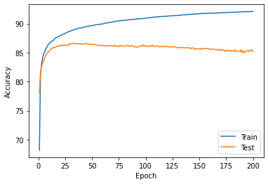

```python
values = np.arange(1,201)
pyplot.plot(values, log['train_accuracy'], label='Train')
pyplot.plot(values, log['test_accuracy'], label='Test')
pyplot.xlabel("Epoch")
pyplot.ylabel("Accuracy")
pyplot.legend()
pyplot.show()
```

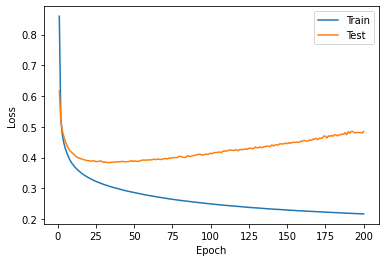

```python
values = np.arange(1,201)
pyplot.plot(values, log['train_loss'], label='Train')
pyplot.plot(values, log['test_loss'], label='Test')
pyplot.xlabel("Epoch")
pyplot.ylabel("Loss")
pyplot.legend()
pyplot.show()
```

#### 10) Draw data with reduced dimension

We made changes to the network to get the output of the layer before the last layer, which contains 2 neurons. The reason for having only two neurons in this layer is that we can easily show the ability of our network to separate classes into two dimensions. In the available diagrams, as can be seen, the network has performed well.

```python
plot_data_test = []
plot_data_train = []
layer_1 = 2

EPOCHS = 30
TRAINLOADER = []
train_loader = Dataloader(trainData, trainLabels, 10, batch_size=32, shuffle=False)
for i in train_loader:
    TRAINLOADER.append(i)
TESTLOADER = []
test_loader = Dataloader(testData, testLabels, 10, batch_size=32, shuffle=False)
for i in test_loader:
    TESTLOADER.append(i)

network = FeedForwardNN(INPUT_SHAPE)
network.add_layer(20, input_shape=INPUT_SHAPE, activation=Relu(), initial_weight='uniform')
network.add_layer(2, activation=Relu(), initial_weight='uniform')
network.add_layer(10, activation=Identical(), initial_weight='uniform')
network.set_training_param(loss=CrossEntropy(), lr=LEARNING_RATE)

log = network.fit(EPOCHS, TRAINLOADER, TESTLOADER)
```

```
Epoch 1:
	Train: Average Accuracy: 46.56	Average Loss: 1.3329950299949493
	Test: Average Accuracy: 66.72324281150159	Average Loss: 0.9340654687156622
Epoch 2:
	Train: Average Accuracy: 68.855	Average Loss: 0.8455076852197321
	Test: Average Accuracy: 71.75519169329074	Average Loss: 0.7781168492334314
Epoch 3:
	Train: Average Accuracy: 73.78166666666667	Average Loss: 0.7396334405934465
	Test: Average Accuracy: 74.21126198083067	Average Loss: 0.7051938429768247
Epoch 4:
	Train: Average Accuracy: 76.03666666666666	Average Loss: 0.6847810832298307
	Test: Average Accuracy: 75.29952076677316	Average Loss: 0.6829372158772662
Epoch 5:
	Train: Average Accuracy: 77.36166666666666	Average Loss: 0.648875289154881
	Test: Average Accuracy: 75.49920127795527	Average Loss: 0.6798899863734292
Epoch 6:
	Train: Average Accuracy: 78.42833333333333	Average Loss: 0.6181550461481098
	Test: Average Accuracy: 76.07827476038338	Average Loss: 0.6577990451324965
Epoch 7:
	Train: Average Accuracy: 79.19833333333334	Average Loss: 0.599103109555173
	Test: Average Accuracy: 77.13658146964856	Average Loss: 0.636922653613631
Epoch 8:
	Train: Average Accuracy: 79.93	Average Loss: 0.5807813393379581
	Test: Average Accuracy: 77.53594249201278	Average Loss: 0.6269380239270871
Epoch 9:
	Train: Average Accuracy: 80.52666666666667	Average Loss: 0.5644903890612829
	Test: Average Accuracy: 79.00359424920129	Average Loss: 0.5995011441472068
Epoch 10:
	Train: Average Accuracy: 80.995	Average Loss: 0.5537437373517647
	Test: Average Accuracy: 78.75399361022365	Average Loss: 0.6099119194553224
Epoch 11:
	Train: Average Accuracy: 81.48	Average Loss: 0.5420399889272567
	Test: Average Accuracy: 78.96365814696486	Average Loss: 0.6075164999996149
Epoch 12:
	Train: Average Accuracy: 81.77333333333333	Average Loss: 0.5327554819195478
	Test: Average Accuracy: 78.94369009584665	Average Loss: 0.6102924873178606
Epoch 13:
	Train: Average Accuracy: 82.15166666666667	Average Loss: 0.5234606416991457
	Test: Average Accuracy: 79.6026357827476	Average Loss: 0.5972378350884178
Epoch 14:
```

[output cut: 35 more lines]

```
Epoch 26:
	Train: Average Accuracy: 84.39833333333333	Average Loss: 0.45611306317903827
	Test: Average Accuracy: 81.51956869009585	Average Loss: 0.5752133705549596
Epoch 27:
	Train: Average Accuracy: 84.57666666666667	Average Loss: 0.4516974437625758
	Test: Average Accuracy: 80.55111821086263	Average Loss: 0.5921521554907775
Epoch 28:
	Train: Average Accuracy: 84.51166666666667	Average Loss: 0.4520380279483273
	Test: Average Accuracy: 80.86062300319489	Average Loss: 0.5875520921584108
Epoch 29:
	Train: Average Accuracy: 84.73333333333333	Average Loss: 0.44775313642541953
	Test: Average Accuracy: 78.91373801916933	Average Loss: 0.6357596349671122
Epoch 30:
	Train: Average Accuracy: 84.74833333333333	Average Loss: 0.44705414222249323
	Test: Average Accuracy: 81.05031948881789	Average Loss: 0.5890784121936764
```

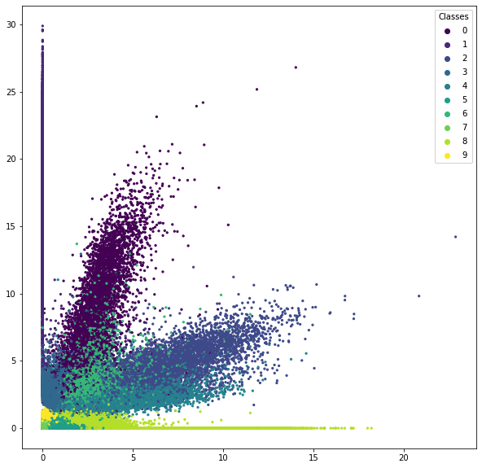

```python
out = np.array(plot_data_train).flatten()
x = out[::2]
y = out[1::2]
c = trainLabels.astype(int)
fig, ax = pyplot.subplots(figsize=(10, 10))
scatter = ax.scatter(x, y, c=c, s=5)
legend1 = ax.legend(*scatter.legend_elements(), title="Classes")
ax.add_artist(legend1)
pyplot.show()
```

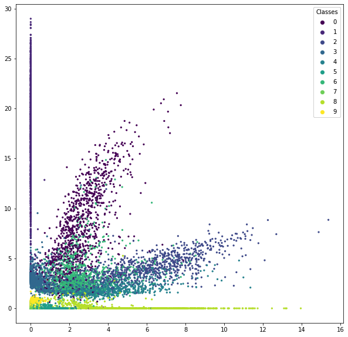

```python
last = plot_data_test.pop()
last = np.array(last).flatten()
out = np.array(plot_data_test).flatten()
out = np.concatenate((out, last))
len(out)
x = out[::2]
y = out[1::2]
c = testLabels.astype(int)
fig, ax = pyplot.subplots(figsize=(10, 10))
scatter = ax.scatter(x, y, c=c, s=5)
legend1 = ax.legend(*scatter.legend_elements(), title="Classes")
ax.add_artist(legend1)
pyplot.show()
```